# R: Arch geoms for GRanges object

| geom_arch {ggbio} | R Documentation |
| --- | --- |

## Arch geoms for GRanges object

### Description

Show interval data as arches.

### Usage

```
## S4 method for signature 'data.frame'
geom_arch(data, ..., n = 25, max.height = 10)


## S4 method for signature 'GRanges'
geom_arch(data, ..., xlab, ylab, main, facets = NULL,
                 rect.height = 0, n = 25, max.height = 10)
```

### Arguments

`data`

A `GRanges` or `data.frame` object.

`...`

Extra parameters passed to autoplot function, `aes` mapping support `height, x, xend`.

- xstart of the arches
- xendend of the arches
- heightheight of arches

`xlab`

Label for x

`ylab`

Label for y

`main`

Title for plot.

`n`

Integer values at which interpolation takes place to create 'n' equally spaced points spanning the interval ['min(x)', 'max(x)'].

`facets`

Faceting formula to use.

`rect.height`

When data is `GRanges`, this padding the arches from original y value to allow users putting arches 'around' the interval rectangles.

`max.height`

Max height of all arches.

### Details

To draw a interval data as arches, we need to provide a special geom for this purpose. Arches is popular in gene viewer or genomoe browser, when they try to show isoforms or gene model.`geom_arch`, just like any other `geom_*` function in ggplot2, you can pass aes() to it to map variable to height of arches.

### Value

A 'Layer'.

### Author(s)

Tengfei Yin

### Examples

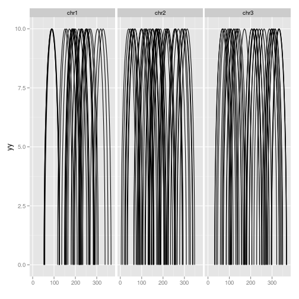

```r
set.seed(1)
N <- 100
library(GenomicRanges)
## =======================================
##  simmulated GRanges
## =======================================
gr <- GRanges(seqnames =
              sample(c("chr1", "chr2", "chr3"),
                     size = N, replace = TRUE),
              IRanges(
                      start = sample(1:300, size = N, replace = TRUE),
                      width = sample(70:75, size = N,replace = TRUE)),
              strand = sample(c("+", "-", "*"), size = N,
                replace = TRUE),
              value = rnorm(N, 10, 3), score = rnorm(N, 100, 30),
              sample = sample(c("Normal", "Tumor"),
                size = N, replace = TRUE),
              pair = sample(letters, size = N,
                replace = TRUE))
## =======================================
##  default
## =======================================
ggplot(gr) + geom_arch()
```

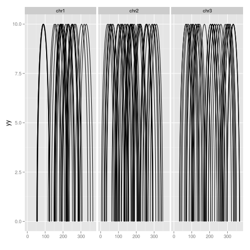

```r
# or
ggplot() + geom_arch(gr)
```

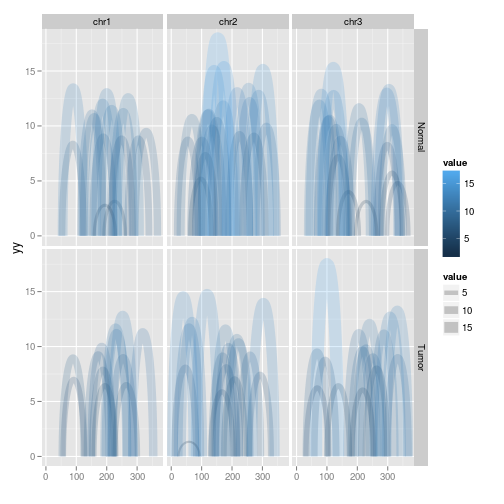

```r
## =======================================
##  facetting and aesthetics
## =======================================
ggplot(gr) + geom_arch(aes(color = value, height = value, size = value),
                     alpha = 0.2, facets = sample ~ seqnames)
```

[Package *ggbio* version 1.5.20 ]